# DATA ANALYSIS PRESENTATION REMINDER

Before starting a dataset, you must understand it to be able to tell interesting stories with it, and not to tell wrong things

- Who is the provider of the dataset ?
- How data has been collected
- Does the dataset represent full population ? Just a sample ? if it's a subset, what are the selection criterias ?
- What each line is representing ?

When you are presenting your results, most of the time, you must use non technical language.

# TD3 : FIRSTNAME STUDY PART 2 : DIVERSITY

```python
%autosave 60
%matplotlib inline
```

```
Autosaving every 60 seconds
```

```python
import warnings
warnings.filterwarnings("ignore")

import pandas as pd
import matplotlib.pyplot as plt

# REMARQUEZ BIEN LE FORMAT DU CHEMIN DE FICHIER
# Dossier qui commence par / = chemin absolu,c-a-d en partant de la racine du disque
# Dossier qui ne commence pas par / = chemin relatif , c-a-d qui commence dans le répértoire courant.

prenoms= pd.read_csv("dpt2018.csv",sep=";")
prenoms
```

|  | sexe | preusuel | annais | dpt | nombre |
| --- | --- | --- | --- | --- | --- |
| 0 | 1 | A | XXXX | XX | 27 |
| 1 | 1 | AADAM | XXXX | XX | 27 |
| 2 | 1 | AADEL | XXXX | XX | 55 |
| 3 | 1 | AADIL | 1983 | 84 | 3 |
| 4 | 1 | AADIL | 1992 | 92 | 3 |
| ... | ... | ... | ... | ... | ... |
| 3624989 | 2 | ÉYA | 2014 | 69 | 3 |
| 3624990 | 2 | ÉYA | XXXX | XX | 23 |
| 3624991 | 2 | ÏNAYA | XXXX | XX | 21 |
| 3624992 | 2 | ÖZGE | XXXX | XX | 30 |
| 3624993 | 2 | ÖZLEM | XXXX | XX | 95 |

3624994 rows × 5 columns

```python
top20=prenoms.groupby("preusuel").nombre.sum().sort_values()[-20:]
top20
```

```
preusuel
DOMINIQUE          409919
PAUL               416412
ROBERT             419297
ROGER              423873
DANIEL             435021
MARCEL             467850
CLAUDE             468445
BERNARD            469399
JACQUES            482812
ALAIN              506899
RENÉ               516739
LOUIS              517774
PHILIPPE           538661
JEANNE             556074
ANDRÉ              712568
MICHEL             820459
PIERRE             891894
_PRENOMS_RARES    1575032
JEAN              1917129
MARIE             2260236
Name: nombre, dtype: int64
```

```python
pip install seaborn
```

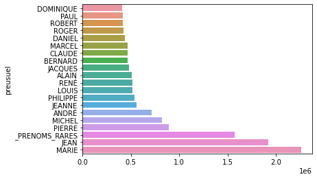

```python
import seaborn as sns
sns.barplot(y=top20.index, x=top20.values)
```

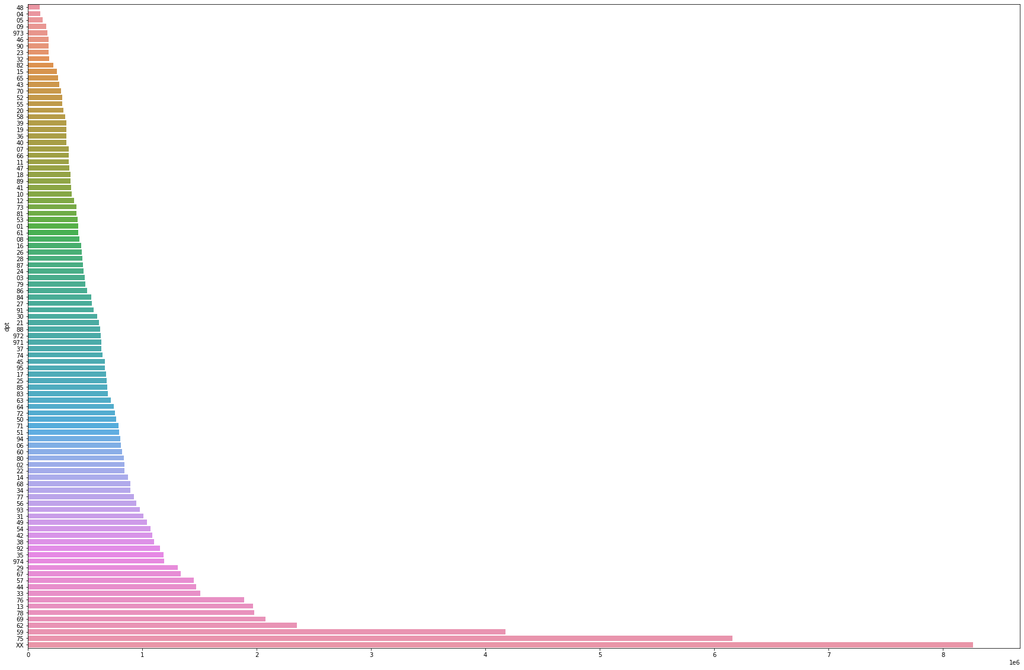

```python
topdep=prenoms.groupby("dpt").nombre.sum().sort_values()
plt.figure(figsize=(30,20))
sns.barplot(y=topdep.index, x=topdep.values)
```

## Creating columns, mapping data using dicts ( // SQL JOIN) , map, replace

We want to add a column in our DataFrame, containing the departments names. We need to find a dataset containing the departement name for each department number. This file exists on the INSEE Website, let's download it : https://www.insee.fr/fr/information/3720946 https://www.insee.fr/fr/statistiques/fichier/3720946/departement2019-csv.zip

```python
dep=pd.read_csv("departement2020.csv",sep=",")
dep
```

|  | dep | reg | cheflieu | tncc | ncc | nccenr | libelle |
| --- | --- | --- | --- | --- | --- | --- | --- |
| 0 | 01 | 84 | 01053 | 5 | AIN | Ain | Ain |
| 1 | 02 | 32 | 02408 | 5 | AISNE | Aisne | Aisne |
| 2 | 03 | 84 | 03190 | 5 | ALLIER | Allier | Allier |
| 3 | 04 | 93 | 04070 | 4 | ALPES DE HAUTE PROVENCE | Alpes-de-Haute-Provence | Alpes-de-Haute-Provence |
| 4 | 05 | 93 | 05061 | 4 | HAUTES ALPES | Hautes-Alpes | Hautes-Alpes |
| ... | ... | ... | ... | ... | ... | ... | ... |
| 96 | 971 | 1 | 97105 | 3 | GUADELOUPE | Guadeloupe | Guadeloupe |
| 97 | 972 | 2 | 97209 | 3 | MARTINIQUE | Martinique | Martinique |
| 98 | 973 | 3 | 97302 | 3 | GUYANE | Guyane | Guyane |
| 99 | 974 | 4 | 97411 | 0 | LA REUNION | La Réunion | La Réunion |
| 100 | 976 | 6 | 97608 | 0 | MAYOTTE | Mayotte | Mayotte |

101 rows × 7 columns

```python
# Sanity check : let's verify number of departements before doing mapping,
# to see if it correspond to the nb of distinct departements number in our dataset


# Number of unique values in a  column
# Equivalent to SQL Select count ( distinct )
prenoms['dpt'].nunique()

# AND NOT prenoms['dpt'].value_counts()
# Equivalent to SQL groupy count ( counts of unique values for each dpt)
```

```
100
```

### We Create a dict from the dataframe

```python
# Fonctions dict et zip qui permettent d'asosocier les deux colonnes du tableau pour obtenir un dictionnaire.
depdict=dict(zip(dep.dep,dep.libelle))
depdict
```

```
{'01': 'Ain',
 '02': 'Aisne',
 '03': 'Allier',
 '04': 'Alpes-de-Haute-Provence',
 '05': 'Hautes-Alpes',
 '06': 'Alpes-Maritimes',
 '07': 'Ardèche',
 '08': 'Ardennes',
 '09': 'Ariège',
 '10': 'Aube',
 '11': 'Aude',
 '12': 'Aveyron',
 '13': 'Bouches-du-Rhône',
 '14': 'Calvados',
 '15': 'Cantal',
 '16': 'Charente',
 '17': 'Charente-Maritime',
 '18': 'Cher',
 '19': 'Corrèze',
 '21': "Côte-d'Or",
 '22': "Côtes-d'Armor",
 '23': 'Creuse',
 '24': 'Dordogne',
 '25': 'Doubs',
 '26': 'Drôme',
 '27': 'Eure',
 '28': 'Eure-et-Loir',
 '29': 'Finistère',
 '2A': 'Corse-du-Sud',
 '2B': 'Haute-Corse',
 '30': 'Gard',
 '31': 'Haute-Garonne',
 '32': 'Gers',
 '33': 'Gironde',
 '34': 'Hérault',
 '35': 'Ille-et-Vilaine',
 '36': 'Indre',
 '37': 'Indre-et-Loire',
 '38': 'Isère',
 '39': 'Jura',
```

[output cut: 46 more lines]

```
 '86': 'Vienne',
 '87': 'Haute-Vienne',
 '88': 'Vosges',
 '89': 'Yonne',
 '90': 'Territoire de Belfort',
 '91': 'Essonne',
 '92': 'Hauts-de-Seine',
 '93': 'Seine-Saint-Denis',
 '94': 'Val-de-Marne',
 '95': "Val-d'Oise",
 '971': 'Guadeloupe',
 '972': 'Martinique',
 '973': 'Guyane',
 '974': 'La Réunion',
 '976': 'Mayotte'}
```

```python
# To do the mapping, ( replace every value with the corresponding value from the dict) we use replace
# replace only replace the value if the key exists in the dict.
# If the key does not exists, it doesn't modify the cell.
prenoms['dpt'].replace(depdict)
```

```
0                      XX
1                      XX
2                      XX
3                Vaucluse
4          Hauts-de-Seine
                ...
3624989             Rhône
3624990                XX
3624991                XX
3624992                XX
3624993                XX
Name: dpt, Length: 3624994, dtype: object
```

```python
prenoms
```

|  | sexe | preusuel | annais | dpt | nombre |
| --- | --- | --- | --- | --- | --- |
| 0 | 1 | A | XXXX | XX | 27 |
| 1 | 1 | AADAM | XXXX | XX | 27 |
| 2 | 1 | AADEL | XXXX | XX | 55 |
| 3 | 1 | AADIL | 1983 | 84 | 3 |
| 4 | 1 | AADIL | 1992 | 92 | 3 |
| ... | ... | ... | ... | ... | ... |
| 3624989 | 2 | ÉYA | 2014 | 69 | 3 |
| 3624990 | 2 | ÉYA | XXXX | XX | 23 |
| 3624991 | 2 | ÏNAYA | XXXX | XX | 21 |
| 3624992 | 2 | ÖZGE | XXXX | XX | 30 |
| 3624993 | 2 | ÖZLEM | XXXX | XX | 95 |

3624994 rows × 5 columns

```python
# WHAT IF IF WANT TO SHOW MORE LINE THAN THE DEFAULT 10 ?
pd.set_option('max_rows',100)
pd.set_option('min_rows',100)

prenoms
```

|  | sexe | preusuel | annais | dpt | nombre |
| --- | --- | --- | --- | --- | --- |
| 0 | 1 | A | XXXX | XX | 27 |
| 1 | 1 | AADAM | XXXX | XX | 27 |
| 2 | 1 | AADEL | XXXX | XX | 55 |
| 3 | 1 | AADIL | 1983 | 84 | 3 |
| 4 | 1 | AADIL | 1992 | 92 | 3 |
| 5 | 1 | AADIL | XXXX | XX | 175 |
| 6 | 1 | AAHIL | 2016 | 95 | 3 |
| 7 | 1 | AAHIL | XXXX | XX | 17 |
| 8 | 1 | AAKASH | XXXX | XX | 26 |
| 9 | 1 | AARON | 1962 | 75 | 3 |
| 10 | 1 | AARON | 1976 | 75 | 3 |
| 11 | 1 | AARON | 1982 | 75 | 3 |
| 12 | 1 | AARON | 1984 | 75 | 3 |
| 13 | 1 | AARON | 1985 | 75 | 5 |
| 14 | 1 | AARON | 1989 | 75 | 3 |
| 15 | 1 | AARON | 1990 | 69 | 3 |
| 16 | 1 | AARON | 1990 | 75 | 4 |
| 17 | 1 | AARON | 1990 | 93 | 4 |
| 18 | 1 | AARON | 1991 | 75 | 5 |
| 19 | 1 | AARON | 1992 | 75 | 6 |
| 20 | 1 | AARON | 1993 | 75 | 5 |
| 21 | 1 | AARON | 1994 | 75 | 8 |
| 22 | 1 | AARON | 1994 | 93 | 3 |
| 23 | 1 | AARON | 1995 | 75 | 10 |
| 24 | 1 | AARON | 1995 | 93 | 6 |
| 25 | 1 | AARON | 1995 | 95 | 3 |
| 26 | 1 | AARON | 1996 | 75 | 12 |
| 27 | 1 | AARON | 1997 | 67 | 3 |
| 28 | 1 | AARON | 1997 | 69 | 3 |
| 29 | 1 | AARON | 1997 | 75 | 23 |

[output cut: 71 more lines]

3624994 rows × 5 columns

```python
# We Create the new column with the output of the mapping
prenoms['nomdep']=prenoms['dpt'].replace(depdict)
```

```python
prenoms
```

|  | sexe | preusuel | annais | dpt | nombre | nomdep |
| --- | --- | --- | --- | --- | --- | --- |
| 0 | 1 | A | XXXX | XX | 27 | XX |
| 1 | 1 | AADAM | XXXX | XX | 27 | XX |
| 2 | 1 | AADEL | XXXX | XX | 55 | XX |
| 3 | 1 | AADIL | 1983 | 84 | 3 | Vaucluse |
| 4 | 1 | AADIL | 1992 | 92 | 3 | Hauts-de-Seine |
| 5 | 1 | AADIL | XXXX | XX | 175 | XX |
| 6 | 1 | AAHIL | 2016 | 95 | 3 | Val-d'Oise |
| 7 | 1 | AAHIL | XXXX | XX | 17 | XX |
| 8 | 1 | AAKASH | XXXX | XX | 26 | XX |
| 9 | 1 | AARON | 1962 | 75 | 3 | Paris |
| 10 | 1 | AARON | 1976 | 75 | 3 | Paris |
| 11 | 1 | AARON | 1982 | 75 | 3 | Paris |
| 12 | 1 | AARON | 1984 | 75 | 3 | Paris |
| 13 | 1 | AARON | 1985 | 75 | 5 | Paris |
| 14 | 1 | AARON | 1989 | 75 | 3 | Paris |
| 15 | 1 | AARON | 1990 | 69 | 3 | Rhône |
| 16 | 1 | AARON | 1990 | 75 | 4 | Paris |
| 17 | 1 | AARON | 1990 | 93 | 4 | Seine-Saint-Denis |
| 18 | 1 | AARON | 1991 | 75 | 5 | Paris |
| 19 | 1 | AARON | 1992 | 75 | 6 | Paris |
| 20 | 1 | AARON | 1993 | 75 | 5 | Paris |
| 21 | 1 | AARON | 1994 | 75 | 8 | Paris |
| 22 | 1 | AARON | 1994 | 93 | 3 | Seine-Saint-Denis |
| 23 | 1 | AARON | 1995 | 75 | 10 | Paris |
| 24 | 1 | AARON | 1995 | 93 | 6 | Seine-Saint-Denis |
| 25 | 1 | AARON | 1995 | 95 | 3 | Val-d'Oise |
| 26 | 1 | AARON | 1996 | 75 | 12 | Paris |
| 27 | 1 | AARON | 1997 | 67 | 3 | Bas-Rhin |
| 28 | 1 | AARON | 1997 | 69 | 3 | Rhône |
| 29 | 1 | AARON | 1997 | 75 | 23 | Paris |

[output cut: 71 more lines]

3624994 rows × 6 columns

```python
# LET'S DO ANOTHER MAPPING, BUT THIS TIME USING A LAMBDA FUNCTION
# we want to add a new column, with H for boys and F for girls
# We use the MAP funnction
prenoms['genre']=prenoms['sexe'].map(lambda x: "H" if x==1 else "F")
prenoms
```

|  | sexe | preusuel | annais | dpt | nombre | nomdep | genre |
| --- | --- | --- | --- | --- | --- | --- | --- |
| 0 | 1 | A | XXXX | XX | 27 | XX | H |
| 1 | 1 | AADAM | XXXX | XX | 27 | XX | H |
| 2 | 1 | AADEL | XXXX | XX | 55 | XX | H |
| 3 | 1 | AADIL | 1983 | 84 | 3 | Vaucluse | H |
| 4 | 1 | AADIL | 1992 | 92 | 3 | Hauts-de-Seine | H |
| ... | ... | ... | ... | ... | ... | ... | ... |
| 3624989 | 2 | ÉYA | 2014 | 69 | 3 | Rhône | F |
| 3624990 | 2 | ÉYA | XXXX | XX | 23 | XX | F |
| 3624991 | 2 | ÏNAYA | XXXX | XX | 21 | XX | F |
| 3624992 | 2 | ÖZGE | XXXX | XX | 30 | XX | F |
| 3624993 | 2 | ÖZLEM | XXXX | XX | 95 | XX | F |

3624994 rows × 7 columns

Dot Notation vs Bracket notation ? https://www.dataschool.io/pandas-dot-notation-vs-brackets/

( path of least resistance )

Retirer Accents ?